# Marker bat acoustic models draft 2

2022-11-28

```r
knitr::opts_chunk$set(echo = F)
knitr::opts_chunk$set(tidy = "styler")
options(knitr.table.format = "html")

# set project working directory according to the user system info
# Otherwise, all the data (inputs and outputs, including figures) can be stored on a shared OneDrive folder

user <- Sys.info()['effective_user']
user
```

```
## effective_user
##         "apmc"
```

```r
# this should print your nmbu user name - "apmc" in my case.

wd <- getwd()
wd
```

```
## [1] "C:/Users/apmc/OneDrive - Norwegian University of Life Sciences/Documents/1. PhD_Main/GitHub_link/MarkerBatAcousticAnalyses/MarkerBatAcousticAnalyses2022/Modeling"
```

```r
# "C:/Users/apmc/OneDrive - Norwegian University of Life Sciences/Documents/1. PhD_Main/GitHub_link/MarkerBatAcousticAnalyses/MarkerBatAcousticAnalyses2022"



### Here is some example code from Pierre that I would like to implement soon which allows us to adjust all the directories based on the user

# if(Sys.info()['user'] == 'pidu') {                                                                                                                                               ## Pierre
#   gitDir <- 'C:/myDocuments/AlpineWolf'
#   dataDir <- 'C:/Users/pidu/Dropbox (AQEG)/AQEG Team Folder/AlpineWolf/01_Data'
#   analysisDir <- 'C:/Users/pidu/Dropbox (AQEG)/AQEG Team Folder/AlpineWolf/02_Analysis'
#   simulationDir <- 'C:/Users/pidu/Dropbox (AQEG)/AQEG Team Folder/AlpineWolf/03_Simulations'
#   meetingDir <- 'C:/Users/pidu/Dropbox (AQEG)/AQEG Team Folder/AlpineWolf/04_Meetings'
#   reportDir <- 'C:/Users/pidu/Dropbox (AQEG)/AQEG Team Folder/AlpineWolf/06_Report'
# } else if(Sys.info()['user'] == 'virginia') {                                                                                                                                ## Virginia
#   gitDir <- '/Users/virginia/Dropbox/Mac/Documents/GitHub/AlpineWolf'
#   dataDir <- '/Users/virginia/Dropbox/AlpineWolf/01_Data'
#   analysisDir <- '/Users/virginia/Dropbox/AlpineWolf/02_Analysis'
#   simulationDir <- '/Users/virginia/Dropbox/AlpineWolf/03_Simulations'
#   meetingDir <- '/Users/virginia/Dropbox/AlpineWolf/04_Meetings'
#   reportDir <- '/Users/virginia/Dropbox/AlpineWolf/06_Report'
#

##########################################################
#### Work environment set up ####
##########################################################
library(knitr)
library(data.table)
library(tidyverse)
library(beepr)
library(lubridate)
library(purrr)
#renv::install("rstudio/renv")
library(renv)
library(stringr)
library(janitor)
library(anytime)
library(kableExtra)
library(papeR)
library(skimr)
library(vtable)
library(gratia)
library(DHARMa)
library(mgcv)
library(tidymv)
##########################################################
#### Import data, set up directories   ####
##########################################################

# All input data can be found on a shared OneDrive folder - we can both share the same input folder but we should have different Output folders.

# for Katrine
#input <- ""

# for Reed
input <- "C:/Users/apmc/OneDrive - Norwegian University of Life Sciences/2. Marker 2019-2020/Marker 2022/SecondDraftAnalyses/Input/forModels"

dataset1 <- "guild_behavior_summarytable_site.csv"
# df2C for the dataset aggregated by guild and bahavior from Marker aggregated to night_all bats
dataset2 <- "totalbatpass_summarytable_withbinary_batpass_night_aggregated_site data.csv"
# df2C for the dataset aggregated to all batsa from Marker aggregated to night_all bats
dataset3 <- "nightlyaggregated_zeros_binary_behavior and guild.csv"
# dataset aggregated to guild and behavior before being table transformed
dataset4 <- "nightlyaggregatedMarker2020_totalbats_zeroinserted_weather_binary.csv"
# dataset aggregated to night by total bats before table transformed
dataset5 <- "guild_behavior_batpass_summarytable_trimmed MRE social and met tower.csv"


path1 <- str_c(input, "/", dataset1)
path2 <- str_c(input, "/", dataset2)
path3 <- str_c(input, "/", dataset3)
path4 <- str_c(input, "/", dataset4)
path5 <- str_c(input, "/", dataset5)

bats_gb <- read_csv(path1) # 11412 obs of 20 variables
```

```
## ──────────────────────────────────────────────────────── Delimiter: "," chr
## (6): Site, guild, behavior, Habitat, Facility, Locality dbl (13): ...1,
## Batpass_sum, Batpass_mean, Batpass_max, batpass01_sum, batp... date (1): night
```

```r
bats_tot <- read.csv(path2) # # 951 obs of 18 variables variables
bats_gb_simple <- read.csv(path3) # 11412 obs of 17 vars
bats_tot_simple <- read.csv(path4) # 951 obs of 15 variables
bats_gb_trim <- read.csv(path5) # 4866 obs of 20 variables

# for Reed
output <- "C:/Users/apmc/OneDrive - Norwegian University of Life Sciences/2. Marker 2019-2020/Marker 2022/SecondDraftAnalyses/Reed/Outputs"

# for Katrine
#output <- ""

##
 file.name <- "Step3.Marker bat acoustics models draft 2"
#
 todays_date <- Sys.Date()
#
dir.name <- str_c(output,"/", file.name, "_", todays_date)
 dir.name
```

```
## [1] "C:/Users/apmc/OneDrive - Norwegian University of Life Sciences/2. Marker 2019-2020/Marker 2022/SecondDraftAnalyses/Reed/Outputs/Step3.Marker bat acoustics models draft 2_2022-12-02"
```

```r
#
 dir.create(dir.name) # be careful not to recreate existing directories
output_today <- dir.name
output_today
```

```
## [1] "C:/Users/apmc/OneDrive - Norwegian University of Life Sciences/2. Marker 2019-2020/Marker 2022/SecondDraftAnalyses/Reed/Outputs/Step3.Marker bat acoustics models draft 2_2022-12-02"
```

# Recommended Youtube videos on GAM to understand the R code below

https://www.youtube.com/watch?v=q4_t8jXcQgc https://www.youtube.com/watch?v=sgw4cu8hrZM&t=4038s

############################################################################# ################ “bats_tot” ################ #############################################################################

The “bats_tot” dataset Nightly aggregated total bat activity

# Preparing the dataset for modeling

Starting with bats total

```
## 'data.frame':    951 obs. of  18 variables:
##  $ X               : int  1 2 3 4 5 6 7 8 9 10 ...
##  $ night           : chr  "2020-07-01" "2020-07-01" "2020-07-01" "2020-07-01" ...
##  $ Site            : chr  "N02" "N08" "N10" "P02" ...
##  $ Batpass_sum     : int  2 6 0 0 0 0 1 0 7 0 ...
##  $ Batpass_mean    : int  2 6 0 0 0 0 1 0 7 0 ...
##  $ Batpass_max     : int  2 6 0 0 0 0 1 0 7 0 ...
##  $ batpass01_sum   : int  1 1 0 0 0 0 1 0 1 0 ...
##  $ batpass01_length: int  1 1 1 1 1 1 1 1 1 1 ...
##  $ wind_mean       : num  4.83 4.83 4.83 4.83 4.83 ...
##  $ wind_min        : num  4.83 4.83 4.83 4.83 4.83 ...
##  $ wind_max        : num  4.83 4.83 4.83 4.83 4.83 ...
##  $ temp_mean       : num  14.8 14.8 14.8 14.8 14.8 ...
##  $ temp_min        : num  14.8 14.8 14.8 14.8 14.8 ...
##  $ temp_max        : num  14.8 14.8 14.8 14.8 14.8 ...
##  $ batpass_prop    : int  1 1 0 0 0 0 1 0 1 0 ...
##  $ Habitat         : chr  "Natural" "Natural" "Natural" "TurbinePad" ...
##  $ Facility        : chr  "North" "North" "South" "North" ...
##  $ Locality        : chr  "Turbine2" "Turbine8" "Turbine10" "Turbine2" ...
```

```
##  [1] "X"                "night"            "Site"             "Batpass_sum"
##  [5] "Batpass_mean"     "Batpass_max"      "batpass01_sum"    "batpass01_length"
##  [9] "wind_mean"        "wind_min"         "wind_max"         "temp_mean"
## [13] "temp_min"         "temp_max"         "batpass_prop"     "Habitat"
## [17] "Facility"         "Locality"
```

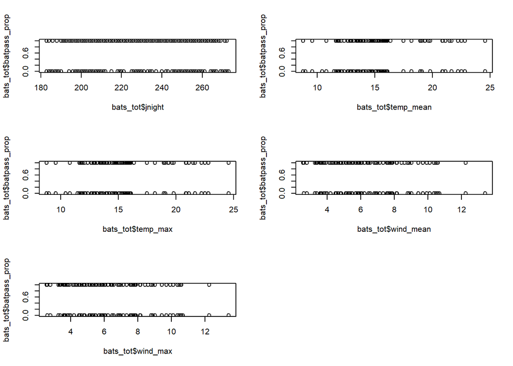

#Steps to prepare binary response (1=batpass, 0 = no batpass)

```
##        X            night                Site      Batpass_sum
##  Min.   :  1.0   Length:951         Met45  : 70   Min.   :  0.00
##  1st Qu.:238.5   Class :character   Met95  : 70   1st Qu.:  1.00
##  Median :476.0   Mode  :character   N08    : 60   Median :  6.00
##  Mean   :476.0                      N10    : 60   Mean   : 20.44
##  3rd Qu.:713.5                      N11    : 60   3rd Qu.: 20.00
##  Max.   :951.0                      N14    : 60   Max.   :659.00
##                                     (Other):571
##   Batpass_mean     Batpass_max     batpass01_sum    batpass01_length
##  Min.   :  0.00   Min.   :  0.00   Min.   :0.0000   Min.   :1
##  1st Qu.:  1.00   1st Qu.:  1.00   1st Qu.:1.0000   1st Qu.:1
##  Median :  6.00   Median :  6.00   Median :1.0000   Median :1
##  Mean   : 20.44   Mean   : 20.44   Mean   :0.8181   Mean   :1
##  3rd Qu.: 20.00   3rd Qu.: 20.00   3rd Qu.:1.0000   3rd Qu.:1
##  Max.   :659.00   Max.   :659.00   Max.   :1.0000   Max.   :1
##
##    wind_mean         wind_min         wind_max        temp_mean
##  Min.   : 2.571   Min.   : 2.571   Min.   : 2.571   Min.   : 8.789
##  1st Qu.: 4.486   1st Qu.: 4.486   1st Qu.: 4.486   1st Qu.:13.419
##  Median : 6.012   Median : 6.012   Median : 6.012   Median :14.930
##  Mean   : 6.249   Mean   : 6.249   Mean   : 6.249   Mean   :15.647
##  3rd Qu.: 7.857   3rd Qu.: 7.857   3rd Qu.: 7.857   3rd Qu.:17.494
##  Max.   :13.413   Max.   :13.413   Max.   :13.413   Max.   :24.579
##
##     temp_min         temp_max       batpass_prop                   Habitat
##  Min.   : 8.789   Min.   : 8.789   Min.   :0.0000   MeteorologicalTower:140
##  1st Qu.:13.419   1st Qu.:13.419   1st Qu.:1.0000   Natural            :391
##  Median :14.930   Median :14.930   Median :1.0000   TurbinePad         :420
##  Mean   :15.647   Mean   :15.647   Mean   :0.8181
##  3rd Qu.:17.494   3rd Qu.:17.494   3rd Qu.:1.0000
##  Max.   :24.579   Max.   :24.579   Max.   :1.0000
##
##   Facility                  Locality       jnight       yes_batpass
##  North:463   MeteorologicalTower:140   Min.   :183.0   Min.   :0.0000
##  South:488   Turbine10          :120   1st Qu.:207.0   1st Qu.:1.0000
##              Turbine11          :120   Median :228.0   Median :1.0000
##              Turbine14          :120   Mean   :228.2   Mean   :0.8181
##              Turbine8           :120   3rd Qu.:250.5   3rd Qu.:1.0000
##              Turbine2           :119   Max.   :273.0   Max.   :1.0000
##              (Other)            :212
##    no_batpass
##  Min.   :0.0000
##  1st Qu.:0.0000
##  Median :0.0000
##  Mean   :0.1819
##  3rd Qu.:0.0000
##  Max.   :1.0000
##
```

#Fitting he full model (I recommend not making the model more complex than this) #Will have to do trial-and-error to get the k right

```
##
## Family: binomial
## Link function: logit
##
## Formula:
## cbind(yes_batpass, no_batpass) ~ s(Locality, bs = "re") + s(jnight,
##     by = Habitat, bs = "gp", k = 90) + Habitat + s(temp_mean) +
##     s(wind_mean) + ti(temp_mean, wind_mean)
##
## Parametric coefficients:
##                   Estimate Std. Error z value Pr(>|z|)
## (Intercept)       -0.03617    0.22151  -0.163     0.87
## HabitatNatural     2.55800    0.29955   8.539  < 2e-16 ***
## HabitatTurbinePad  3.24277    0.46442   6.982  2.9e-12 ***
## ---
## Signif. codes:  0 '***' 0.001 '**' 0.01 '*' 0.05 '.' 0.1 ' ' 1
##
## Approximate significance of smooth terms:
##                                            edf Ref.df Chi.sq  p-value
## s(Locality)                          0.3433791      6  0.358 0.386901
## s(jnight):HabitatMeteorologicalTower 0.0000476     72  0.000 0.877886
## s(jnight):HabitatNatural             2.5330933     87  8.624 0.012154 *
## s(jnight):HabitatTurbinePad          5.6185246     88 40.312  < 2e-16 ***
## s(temp_mean)                         2.2539415      9 20.685 1.02e-06 ***
## s(wind_mean)                         3.2134647      9 20.946 7.11e-06 ***
## ti(temp_mean,wind_mean)              4.8139882     16 17.980 0.000105 ***
## ---
## Signif. codes:  0 '***' 0.001 '**' 0.01 '*' 0.05 '.' 0.1 ' ' 1
##
## R-sq.(adj) =  0.369   Deviance explained = 37.5%
## -REML = 319.49  Scale est. = 1         n = 951
```

### Katrine:

The reason why I use GAM with a rather simple random effect instead of GAMM, is that there are fewer options (e.g., distributions) available in GAMM

Model validation (may also use dHARMA to get more fancy validation plots) Note that validation if binomial models is usually a pain and does not give meaningful validation plots However, it works in our case, because of the aggregated nature of the data :-) I found a similar example in https://www.youtube.com/watch?v=sgw4cu8hrZM&t=4038s

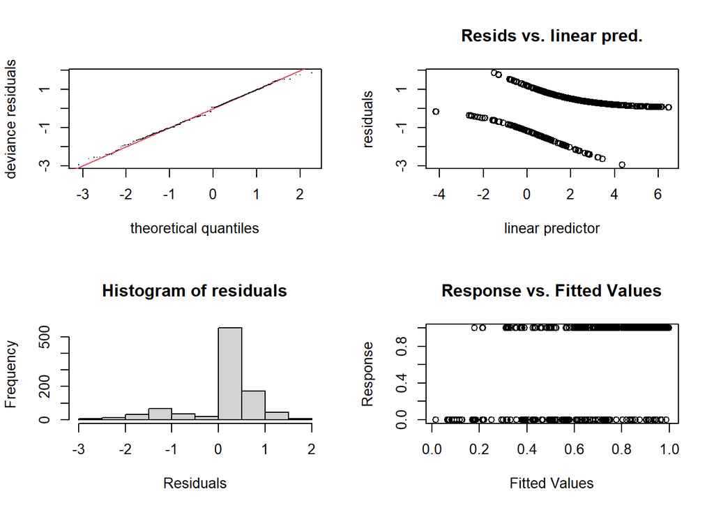

```
##
## Method: REML   Optimizer: outer newton
## full convergence after 21 iterations.
## Gradient range [-3.297958e-05,1.583296e-05]
## (score 319.4884 & scale 1).
## Hessian positive definite, eigenvalue range [2.344473e-06,0.7420669].
## Model rank =  312 / 312
##
## Basis dimension (k) checking results. Low p-value (k-index<1) may
## indicate that k is too low, especially if edf is close to k'.
##
##                                            k'      edf k-index p-value
## s(Locality)                          8.00e+00 3.43e-01      NA      NA
## s(jnight):HabitatMeteorologicalTower 8.90e+01 4.76e-05    0.95    0.21
## s(jnight):HabitatNatural             8.90e+01 2.53e+00    0.95    0.20
## s(jnight):HabitatTurbinePad          8.90e+01 5.62e+00    0.95    0.20
## s(temp_mean)                         9.00e+00 2.25e+00    0.96    0.31
## s(wind_mean)                         9.00e+00 3.21e+00    0.94    0.11
## ti(temp_mean,wind_mean)              1.60e+01 4.81e+00    0.85  <2e-16 ***
## ---
## Signif. codes:  0 '***' 0.001 '**' 0.01 '*' 0.05 '.' 0.1 ' ' 1
```

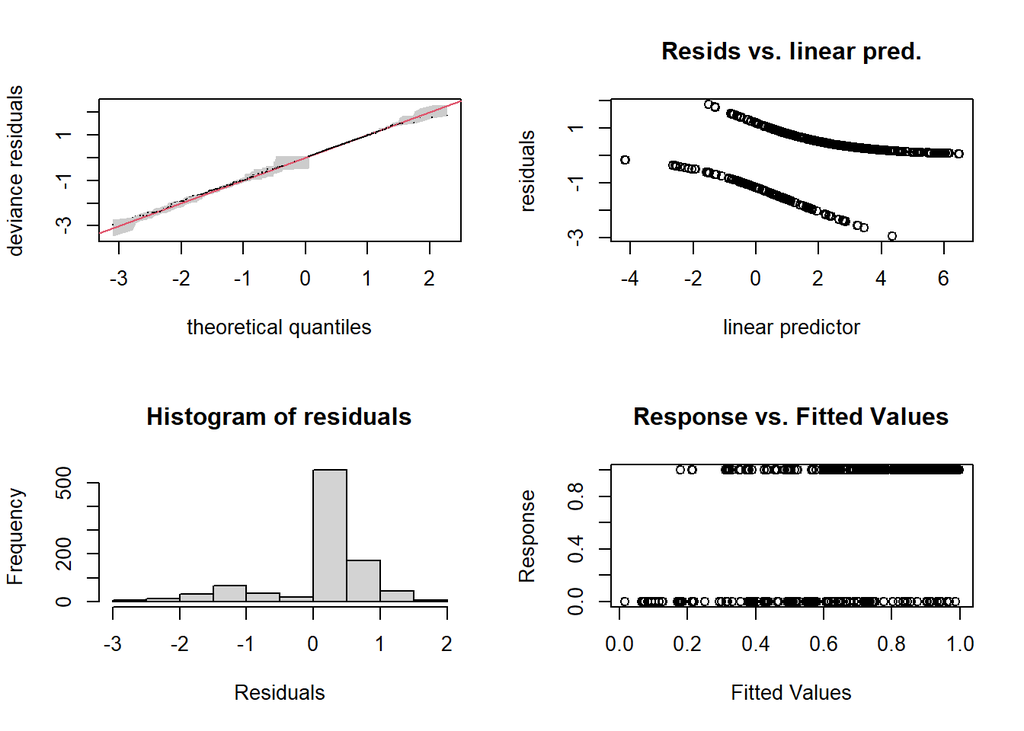

```
##
## Method: REML   Optimizer: outer newton
## full convergence after 21 iterations.
## Gradient range [-3.297958e-05,1.583296e-05]
## (score 319.4884 & scale 1).
## Hessian positive definite, eigenvalue range [2.344473e-06,0.7420669].
## Model rank =  312 / 312
##
## Basis dimension (k) checking results. Low p-value (k-index<1) may
## indicate that k is too low, especially if edf is close to k'.
##
##                                            k'      edf k-index p-value
## s(Locality)                          8.00e+00 3.43e-01      NA      NA
## s(jnight):HabitatMeteorologicalTower 8.90e+01 4.76e-05    0.95    0.18
## s(jnight):HabitatNatural             8.90e+01 2.53e+00    0.95    0.26
## s(jnight):HabitatTurbinePad          8.90e+01 5.62e+00    0.95    0.21
## s(temp_mean)                         9.00e+00 2.25e+00    0.96    0.28
## s(wind_mean)                         9.00e+00 3.21e+00    0.94    0.10 .
## ti(temp_mean,wind_mean)              1.60e+01 4.81e+00    0.85  <2e-16 ***
## ---
## Signif. codes:  0 '***' 0.001 '**' 0.01 '*' 0.05 '.' 0.1 ' ' 1
```

```
## [1] 0.80653
```

# Basis dimension (k) checking results:

The k-index should be approx. 1 or larger Play play around with k….

# m2

# model temperature as linear effect

```
##
## Family: binomial
## Link function: logit
##
## Formula:
## cbind(yes_batpass, no_batpass) ~ s(Locality, bs = "re") + s(jnight,
##     by = Habitat, bs = "gp", k = 90) + Habitat + temp_mean +
##     s(wind_mean) + ti(temp_mean, wind_mean)
##
## Parametric coefficients:
##                   Estimate Std. Error z value Pr(>|z|)
## (Intercept)       -4.55691    1.17998  -3.862 0.000113 ***
## HabitatNatural     2.56588    0.30225   8.489  < 2e-16 ***
## HabitatTurbinePad  3.28247    0.48768   6.731 1.69e-11 ***
## temp_mean          0.29795    0.07437   4.006 6.17e-05 ***
## ---
## Signif. codes:  0 '***' 0.001 '**' 0.01 '*' 0.05 '.' 0.1 ' ' 1
##
## Approximate significance of smooth terms:
##                                            edf Ref.df Chi.sq  p-value
## s(Locality)                          3.408e-01      6  0.356 0.386191
## s(jnight):HabitatMeteorologicalTower 6.452e-05     77  0.000 0.887360
## s(jnight):HabitatNatural             2.843e+00     87 10.464 0.006340 **
## s(jnight):HabitatTurbinePad          6.074e+00     88 40.997  < 2e-16 ***
## s(wind_mean)                         3.236e+00      9 16.919 4.24e-05 ***
## ti(temp_mean,wind_mean)              5.346e+00     16 18.645 0.000382 ***
## ---
## Signif. codes:  0 '***' 0.001 '**' 0.01 '*' 0.05 '.' 0.1 ' ' 1
##
## R-sq.(adj) =  0.365   Deviance explained = 37.4%
## -REML = 320.47  Scale est. = 1         n = 951
```

# Basis dimension (k) checking results:

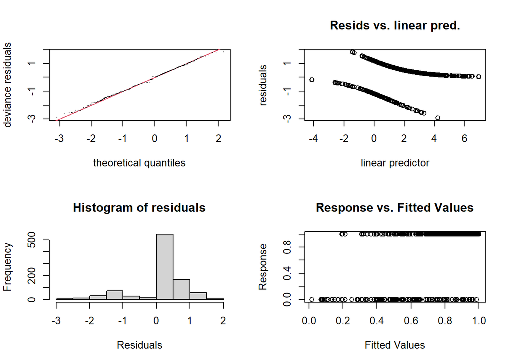

```
##
## Method: REML   Optimizer: outer newton
## full convergence after 18 iterations.
## Gradient range [-9.303033e-05,4.008943e-05]
## (score 320.4746 & scale 1).
## Hessian positive definite, eigenvalue range [2.88257e-06,0.7431721].
## Model rank =  304 / 304
##
## Basis dimension (k) checking results. Low p-value (k-index<1) may
## indicate that k is too low, especially if edf is close to k'.
##
##                                            k'      edf k-index p-value
## s(Locality)                          8.00e+00 3.41e-01      NA      NA
## s(jnight):HabitatMeteorologicalTower 8.90e+01 6.45e-05    0.95    0.25
## s(jnight):HabitatNatural             8.90e+01 2.84e+00    0.95    0.21
## s(jnight):HabitatTurbinePad          8.90e+01 6.07e+00    0.95    0.22
## s(wind_mean)                         9.00e+00 3.24e+00    0.94    0.10
## ti(temp_mean,wind_mean)              1.60e+01 5.35e+00    0.85  <2e-16 ***
## ---
## Signif. codes:  0 '***' 0.001 '**' 0.01 '*' 0.05 '.' 0.1 ' ' 1
```

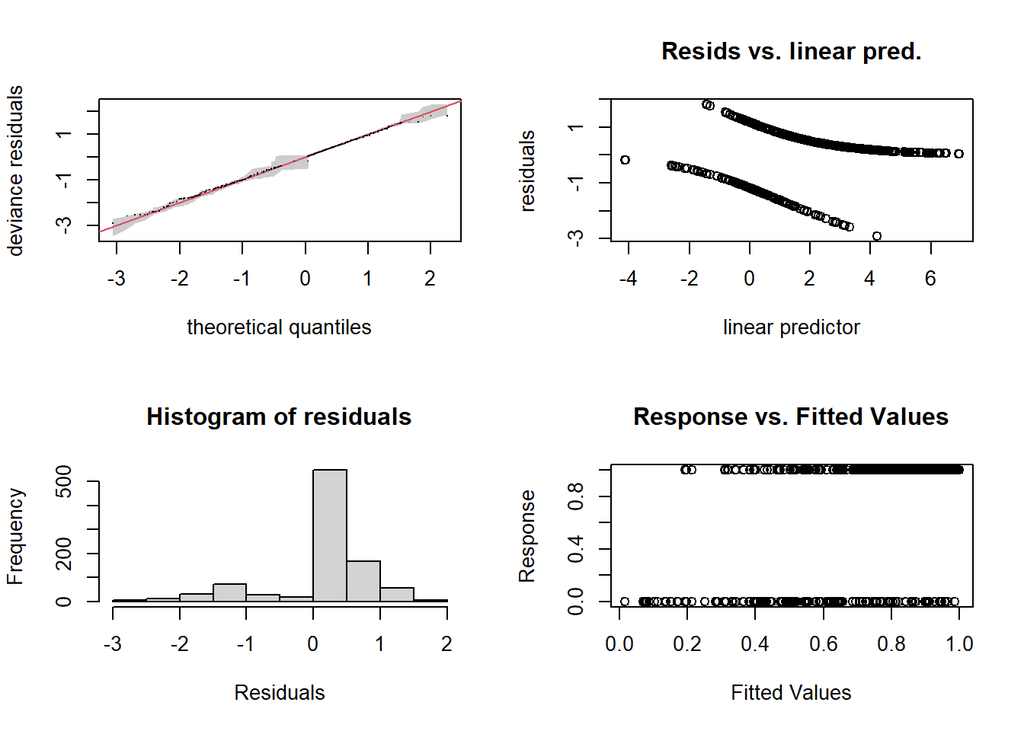

```
##
## Method: REML   Optimizer: outer newton
## full convergence after 18 iterations.
## Gradient range [-9.303033e-05,4.008943e-05]
## (score 320.4746 & scale 1).
## Hessian positive definite, eigenvalue range [2.88257e-06,0.7431721].
## Model rank =  304 / 304
##
## Basis dimension (k) checking results. Low p-value (k-index<1) may
## indicate that k is too low, especially if edf is close to k'.
##
##                                            k'      edf k-index p-value
## s(Locality)                          8.00e+00 3.41e-01      NA      NA
## s(jnight):HabitatMeteorologicalTower 8.90e+01 6.45e-05    0.95    0.20
## s(jnight):HabitatNatural             8.90e+01 2.84e+00    0.95    0.20
## s(jnight):HabitatTurbinePad          8.90e+01 6.07e+00    0.95    0.21
## s(wind_mean)                         9.00e+00 3.24e+00    0.94    0.10 .
## ti(temp_mean,wind_mean)              1.60e+01 5.35e+00    0.85  <2e-16 ***
## ---
## Signif. codes:  0 '***' 0.001 '**' 0.01 '*' 0.05 '.' 0.1 ' ' 1
```

```
## [1] 0.7804294
```

# Basis dimension (k) checking results:

The k-index should be approx. 1 or larger Play play around with k….

# This model is more under dispersed than the last one and the issue of an ill-fitting k value is still there.